# HWK5_Mohammadhossein Toutiaee

#### Program Name: SAS Programming

#### Author: Mohammadhossein Toutiaee

#### Written: 19/02/17

#### Dataset Description:

The file fred.sas7bat contains data on 143 bicycle rides taken in 2013 by Fred, an amateur athlete and cycling enthusiast. The dataset includes the following variables: date, the date on which the ride was take; time, the elapsed time (or duration) of the ride; distance, the length in miles of the ride; elgain, the total (not net) elevation gain during the ride; avgspd, Fred’s average speed (mi/hr) during the ride; maxspd, Fred’s maximum speed during the ride; avghr, Fred’s average heart rate during the ride; maxhr, Fred’s maximum heart rate during the ride; cals, the number of calories Fred burned during the ride; and strokes, the number of pedal strokes Fred made during the ride. These data were collected from Fred’s cycling computer. During the year Fred noticed some malfunctions in his cycling computer, so he knows that there are a few mistakes in the dataset as well as some missing values (but most of the missing values are for the variable strokes, which we are not going to use in this problem).  
I coded a SAS program that sets the Fred dataset into a new dataset and create the following new variables: logdist, the natural logarithm of distance; elgrad, the elevation gradient equal to the ratio of elgain to distance (this variable measures how steep the bike route was); and I created an indicator called calgroup for whether the ride was after January 18, 2013. The reason for calgroup is that Fred’s cycling computer computes calories burned for each ride, but Fred had not entered his personal data (his weight, fitness level, etc.) into the computer until after the January 18 bike ride, so the calorie calculation was calibrated differently after that date as compared with the first few rides of 2013.

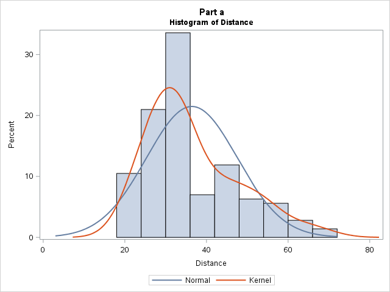

```sas
libname SASdata "/folders/myshortcuts/myFolders/Data Files";

************Prepare the new dataset*************;

proc format; *format calgroup;
  value cal_format 1='Before January 18' 2="After January 18";
run;


data sasdata.fred_new;
  set sasdata.fred; *copy from the original dataset;

  if (date <= '18jan2013'd)
      then calgroup=1;
  else calgroup = 2;    *choose cal group based on date;

  format calgroup cal_format.;

  if calgroup=2
     then calfixed=cals;
  else calfixed=.;

  if calgroup=1
     then calnotfixed=cals;
  else calnotfixed=.;


  logdist=log(distance);

  elgrad=elgain/distance;

  format date mmddyy8. time time8.0;

  label avgspd="AverageSpeed" avghr="AverageHeartrate" cals="CaloriesBurned" time="Duration" distance="Distance" date="Date" elgrad="ElevationGradient" logdist="LogDistance" calfixed="CaloriesBurned"  calnotfixed="CaloriesBurned";
run;

*********Part a**********;
title "Part a";
title2 "Histogram of Distance";

proc sgplot data=sasdata.fred_new;
  histogram distance;
  density distance;
  density distance/type=kernel;
run;
```

**(a) Does distance appear to be normally distributed? Why or why not?**  
No. It seems to be skewed right. That is, the distribution appears not to be symmetric, with too many extremely large values of distance for it to be normal.

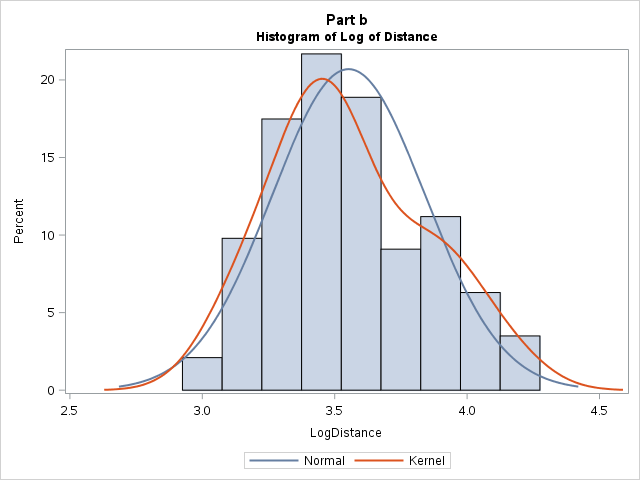

```sas
*********Part b**********;

title "Part b";
title2 "Histogram of Log of Distance";

proc sgplot data=sasdata.fred_new;
  histogram logdist;
  density logdist;
  density logdist/type=kernel;
run;
```

**(b) Is logdist more nearly normally distributed than distance?**  
Yes. The log transformation shrinks the largest values more than it shrinks smaller values, so this transformation makes the distribution more nearly symmetric and normally distributed. The distribution is not exacatly normal even after the transformation, but it is certainly closer to normal.

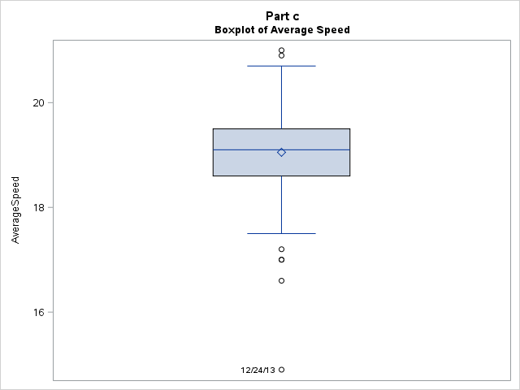

```sas
*********Part c**********;

title "Part c";
title2 "Boxplot of Average Speed";

proc sgplot data=sasdata.fred_new;
  vbox avgspd/datalabel=date labelfar; *“far outlier” is any data value that is more than 3 times the intra-quartile range outside of the box;
run;
```

**(c) On what date(s) did the far outlier(s) occur?**  
There is just one far outlier. It occurred on Dec. 24, 2013.

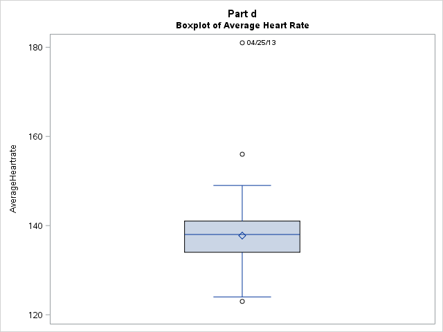

```sas
*********Part d**********;

title "Part d";
title2 "Boxplot of Average Heart Rate";

proc sgplot data=sasdata.fred_new;
  vbox avghr/datalabel=date labelfar;
run;
```

**(d) On what date(s) did the far outlier(s) occur?**  
There is just one far outlier. It occurred on Apr. 25, 2013.

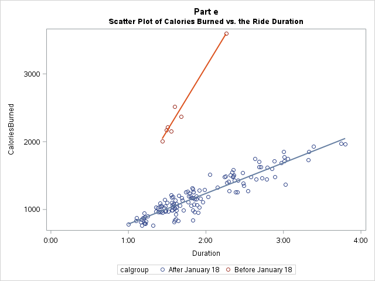

```sas
********Part e**********;

title "Part e";
title2 "Scatter Plot of Calories Burned vs. the Ride Duration";

proc sgplot data=sasdata.fred_new;
  where date not in ('25apr2013'd,'24dec2013'd); * omit the outliers of previous parts;

  scatter x=time y=cals /group=calgroup;
  reg x=time y=calfixed/nomarkers;
  reg x=time y=calnotfixed/nomarkers;

run;
```

**(e) Do the calorie values seem to be computed differently after Jan. 18?**  
Yes. Clearly the calories calculations before Jan.19 are much larger and increase more quickly with the distance of the ride than after Jan.18.

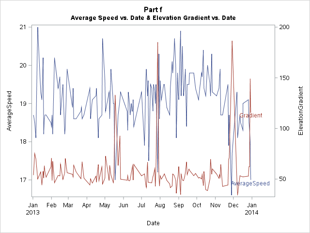

```sas
********Part f**********;

title "Part f";
title2 "Average Speed vs. Date & Elevation Gradient vs. Date";

proc sgplot data=sasdata.fred_new;

  where date not in ('25apr2013'd,'24dec2013'd); * omit the outliers of previous parts;

  series x=date y=avgspd /curvelabel="AverageSpeed" curvelabelpos=start;
  series x=date y=elgrad/y2axis curvelabel="Gradient" curvelabelpos=start;

run;
```

**(f) Do you notice any relationship between average speed and elevation gradient?**  
Average speed and gradient do not seem to be strongly related, but it is certainly noticeable that when gradient is very high, average speed is low. Of course, this is understandable. It is hard to go fast up a steep hill!

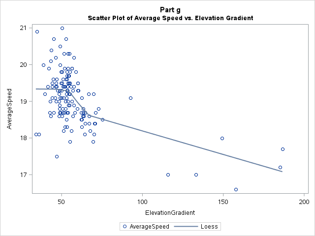

```sas
********Part g**********;

title "Part g";
title2 "Scatter Plot of Average Speed vs. Elevation Gradient";

proc sgplot data=sasdata.fred_new;

  where date not in ('25apr2013'd,'24dec2013'd); * omit the outliers of previous parts;

  scatter x=elgrad y=avgspd ;
  loess x=elgrad y=avgspd/nomarkers;

run;
```

**(g) Comment briefly on the nature of the apparent relationship between these variables, if any.**  
There is a slight negative relationship.

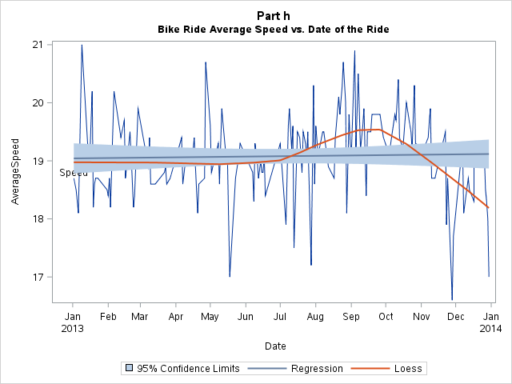

```sas
********Part h**********;

title "Part h";
title2 "Bike Ride Average Speed vs. Date of the Ride";

proc sgplot data=sasdata.fred_new;

  where date not in ('25apr2013'd,'24dec2013'd); * omit the outliers of previous parts;

  series x=date y=avgspd / curvelabel="Speed";
  reg x=date y=avgspd /nomarkers  clm;
  loess x=date y=avgspd/nomarkers;

run;
```

**(h) Does the fitted regression model suggest that Fred's average speed has gone up during the year? Does the regression model seem to fit these data well? Why or why not?**  
The fitted regression line is almost perfectly flat. We would have to look at the regression coefficients and their t-statistics to determine if the slope is significantly different from 0, but it appears not to be, suggesting that Fred’s pace has not increased during the year. However, a simple linear regression model doesn’t appear to fit these data well. The data seem to increase over time after mid-year, peaking in September or October. Then, in November and December Fred’s pace exhibits a steep decline. This is shown clearly by the loess line. Therefore, the regression line is somewhat misleading; it over-simplifies the pattern that the data actually exhibit.

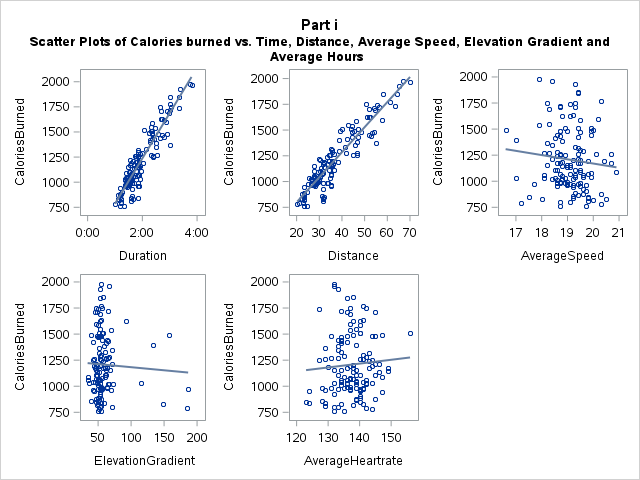

```sas
********Part i**********;

title "Part i";
title2 "Scatter Plots of Calories burned vs. Time, Distance, Average Speed, Elevation Gradient and Average Hours";

proc sgscatter data=sasdata.fred_new;

   where date not in ('25apr2013'd,'24dec2013'd); * omit the outliers of previous parts;

  plot (calfixed)*(time distance avgspd elgrad avghr)/ reg;
run;
```

**(i) Which variables are positively related to calories? Which variables are negatively related to calories? Whuch variables appear most strongly related to calories?**  
Calories burned is positively related to time, distance and average heart rate. It is negatively associated with average speed and elevation gradient. The strongest relationships are with time and distance.

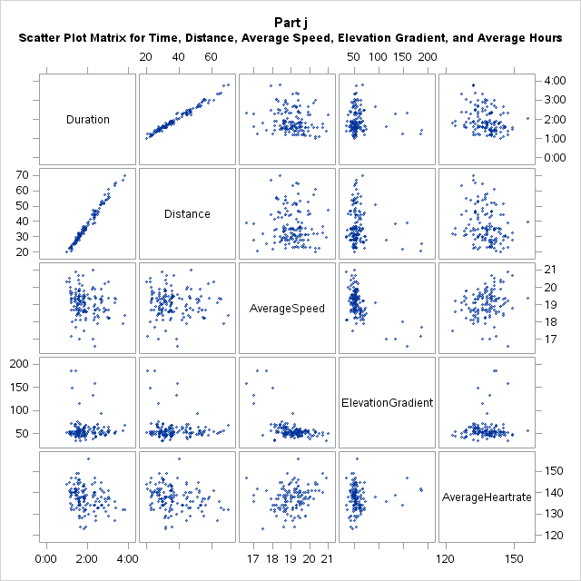

```sas
********Part j**********;

title "Part j";
title2 "Scatter Plot Matrix for Time, Distance, Average Speed, Elevation Gradient, and Average Hours";

proc sgscatter data=sasdata.fred_new;
  where date not in ('25apr2013'd,'24dec2013'd); * omit the outliers of previous parts;

  matrix time distance avgspd elgrad avghr;
run;
```

**(j) Which two variables appear to be most strongly correlated?**  
Time and distance are very strongly positively correlated. (No surprise – it takes longer to ride a long distance than a short distance!)